# 6. Analysis of longitudinal data

*This file describes the work and results of the sixth week a. k. a. “Analysis of longitudinal data” of the IDOS2023 course.*

### 6.1 Simple analysis method on RATS data: Graphical and numerical overview

Many studies in the behavioral sciences involve several measurement or observations of the response variable of interest on each subject in the study. For example, the response variable may be measured under a number of different experimental conditions or on a number of different occasions over time; such data are labelled repeated measures or *longitudinal data*. Longitudinal data poses problems for analysis because the repeated measurements on each subject are very likely to be correlated rather than independent.

Graphical displays of data are almost always useful for exposing patterns in the data, particularly when these are unexpected; this might be of great help in suggesting which class of models might be most sensibly applied in the later more formal analysis. It is important to note that the simple methods should be used only in the initial stage of dealing with the data; more appropriate methods will be discussed in 6.2.

Source: Multivariate Analysis for the Behavioral Sciences, Second Edition (2019), special version for IODS course. Note that the text is not paraphrased.

#### 6.1.1 Scatter plot

We perform the first simple analysis on the RATS data set, in which groups of rats were put on different diets to see if the growth profiles differ between the groups. Each rat’s body weight (in grams) was recorded approximately every week for a period of 9 weeks, except for week seven, in which two measurements where taken. First, we create a plot where we separate the three different rat groups, showing their weight in grams (y-axis) over the 9-week-period of their diet (see below).

```r
# load necessary libraries
library(ggplot2)
library(dplyr)
# load in data set
RATS <- read.csv(file = "/home/ntriches/github_iods2023/IODS23/data/rats.csv", header = TRUE)
str(RATS) # ID and Group are not factors
```

```
## 'data.frame':    176 obs. of  5 variables:
##  $ ID    : int  1 2 3 4 5 6 7 8 9 10 ...
##  $ Group : int  1 1 1 1 1 1 1 1 2 2 ...
##  $ WD    : chr  "WD1" "WD1" "WD1" "WD1" ...
##  $ Weight: int  240 225 245 260 255 260 275 245 410 405 ...
##  $ Time  : int  1 1 1 1 1 1 1 1 1 1 ...
```

```r
# RATS: factor Id and group
RATS$ID <- factor(RATS$ID)
RATS$Group <- factor(RATS$Group)
str(RATS)
```

```
## 'data.frame':    176 obs. of  5 variables:
##  $ ID    : Factor w/ 16 levels "1","2","3","4",..: 1 2 3 4 5 6 7 8 9 10 ...
##  $ Group : Factor w/ 3 levels "1","2","3": 1 1 1 1 1 1 1 1 2 2 ...
##  $ WD    : chr  "WD1" "WD1" "WD1" "WD1" ...
##  $ Weight: int  240 225 245 260 255 260 275 245 410 405 ...
##  $ Time  : int  1 1 1 1 1 1 1 1 1 1 ...
```

```r
summary(RATS)
```

```
##        ID      Group       WD                Weight           Time
##  1      : 11   1:88   Length:176         Min.   :225.0   Min.   : 1.00
##  2      : 11   2:44   Class :character   1st Qu.:267.0   1st Qu.:15.00
##  3      : 11   3:44   Mode  :character   Median :344.5   Median :36.00
##  4      : 11                             Mean   :384.5   Mean   :33.55
##  5      : 11                             3rd Qu.:511.2   3rd Qu.:50.00
##  6      : 11                             Max.   :628.0   Max.   :64.00
##  (Other):110
```

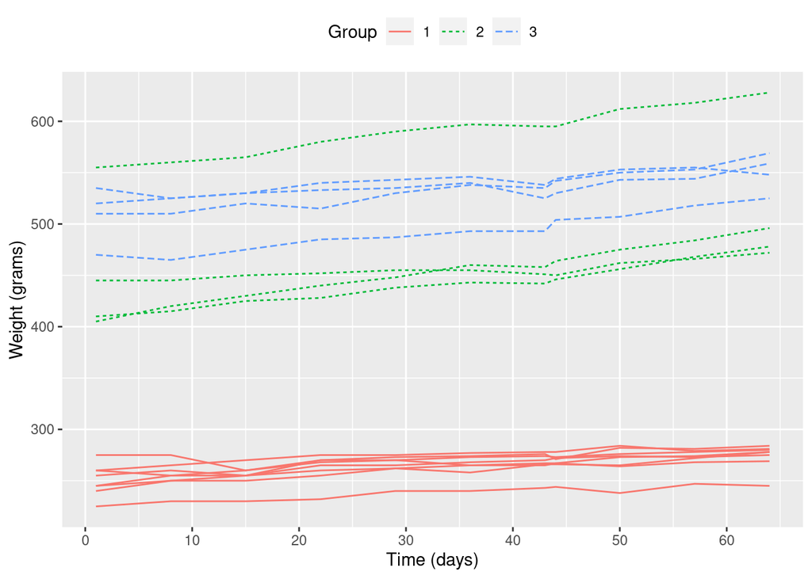

```r
# plot
ggplot(RATS, aes(x = Time, y = Weight, group = ID)) +
  geom_line(aes(linetype = Group, colour = Group)) +
  scale_x_continuous(name = "Time (days)", breaks = seq(0, 60, 10)) +
  scale_y_continuous(name = "Weight (grams)") +
  theme(legend.position = "top")
```

$$standardised(x) = \frac{x - mean(x)}{
sd(x)}$$

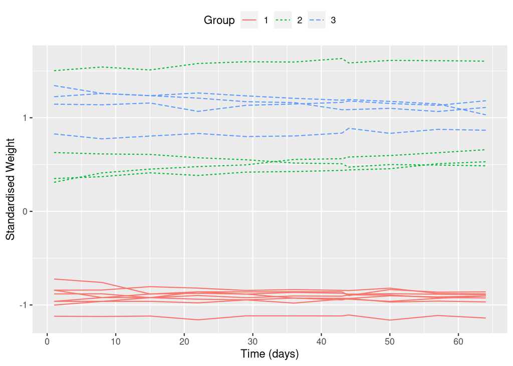

```r
library(tidyr)
# standardise the variable weight (grams)
RATS <- RATS %>%
  group_by(Time) %>%
  mutate(StdWeight= (Weight - mean(Weight))/sd(Weight)) %>%
  ungroup()
# plot again with the standardised weights
ggplot(RATS, aes(x = Time, y = StdWeight, group = ID)) +
  geom_line(aes(linetype = Group, colour = Group)) +
  scale_x_continuous(name = "Time (days)", breaks = seq(0, 60, 10)) +
  scale_y_continuous(name = "Standardised Weight") +
  theme(legend.position = "top")
```

By standardising variables, we can see the scales effect on some variables differently. In this case, however, the overall picture does not show any difference and does not reveal more information.

#### 6.1.2 Summary graphs

With large numbers of observations, graphical displays of individual response profiles do not show us very much. Instead, we can produce graphs showing us the average (mean) profiles for each treatment group, along with some indication of the variation of the observations at each time point, in this case the standard error of mean:

$$se = \frac{sd(x)}{\sqrt{n}}$$

```r
# Summary data with mean and standard error of weight by group and time (days)
# number of ID per group
RATS_summary <- RATS %>%
  group_by(Group, Time) %>%
    summarise(mean = mean(Weight, na.rm = TRUE),
              n    = n(),
              se   = sd(Weight)/sqrt(n)) %>%
  ungroup()
```

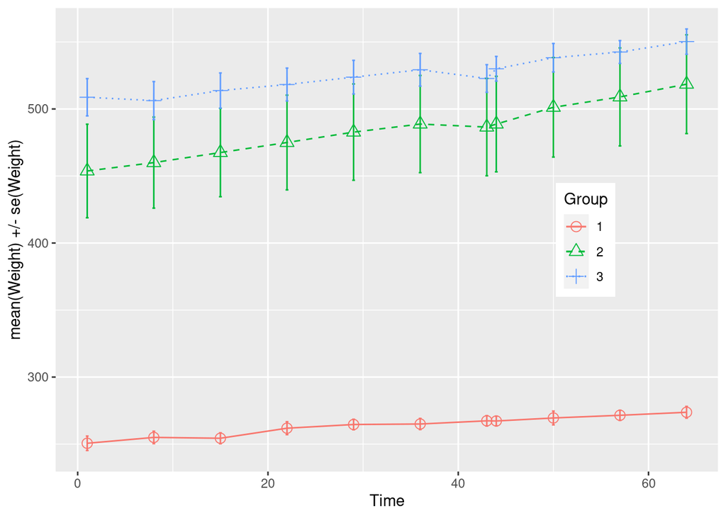

```r
# Plot the mean profiles
library(ggplot2)
ggplot(RATS_summary, aes(x = Time, y = mean, linetype = Group, shape = Group, colour = Group)) +
  geom_line() +
  scale_linetype_manual(values = c(1,2,3)) +
  geom_point(size=3) +
  scale_shape_manual(values = c(1,2,3)) +
  geom_errorbar(aes(ymin=mean-se, ymax=mean+se, linetype="1"), width=0.3) +
  theme(legend.position = c(0.8,0.5)) +
  scale_y_continuous(name = "mean(Weight) +/- se(Weight)")
```

```r
# Create a summary data by group and ID with mean as the summary variable
RATS_summary_groupID <- RATS%>%
  group_by(Group, ID) %>%
  summarise(mean=mean(Weight)) %>%
  ungroup()
# Glimpse the data
glimpse(RATS_summary_groupID)
```

```
## Rows: 16
## Columns: 3
## $ Group <fct> 1, 1, 1, 1, 1, 1, 1, 1, 2, 2, 2, 2, 3, 3, 3, 3
## $ ID    <fct> 1, 2, 3, 4, 5, 6, 7, 8, 9, 10, 11, 12, 13, 14, 15, 16
## $ mean  <dbl> 261.0909, 237.6364, 260.1818, 266.5455, 269.4545, 274.7273, 274.…
```

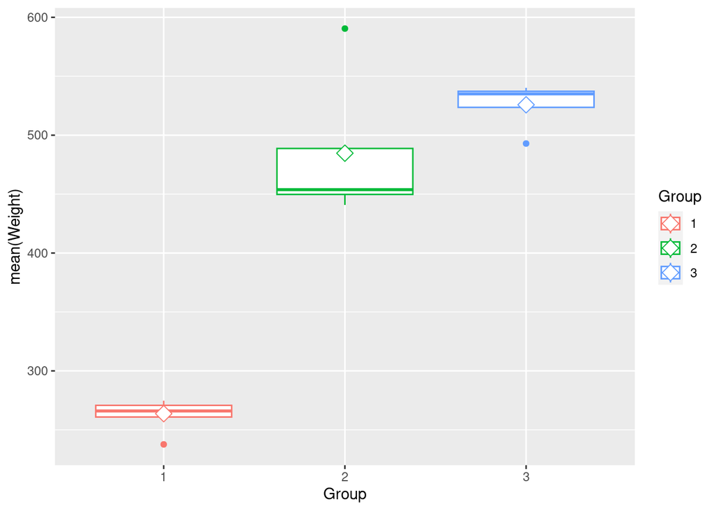

```r
# Draw a boxplot of the mean versus treatment
library(ggplot2)
ggplot(RATS_summary_groupID, aes(x = Group, y = mean, colour = Group)) +
  geom_boxplot() +
  stat_summary(fun = "mean", geom = "point", shape=23, size=4, fill = "white") +
  scale_y_continuous(name = "mean(Weight)")
```

```r
# remove outliers in group 1 and 2
RATS_summary_groupID_noOutliers <- RATS%>%
  filter(!Weight < 250,
         !Weight > 550) %>%
  group_by(Group, ID) %>%
  summarise(mean=mean(Weight)) %>%
  ungroup()
```

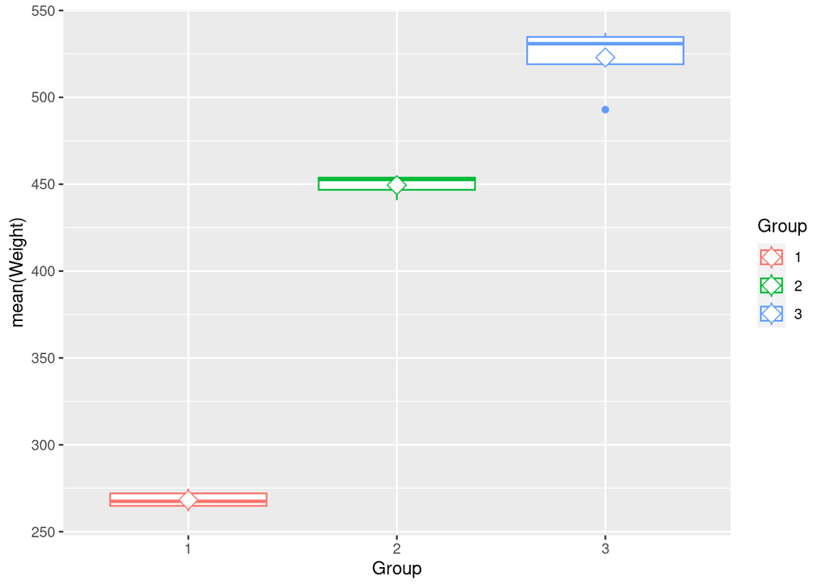

```r
# plot without 2 extreme outliers
ggplot(RATS_summary_groupID_noOutliers, aes(x = Group, y = mean, colour = Group)) +
  geom_boxplot() +
  stat_summary(fun = "mean", geom = "point", shape=23, size=4, fill = "white") +
  scale_y_continuous(name = "mean(Weight)")
```

From the plots above, we can see that rats in group 1 are considerably lighter than group 2 and 3. Groups 2 and 3 are much closer, with group 2 showing the highest within-group variation of all groups. It is evident that each group has one outlier. In group 1, there seems to be a very light rat, whereas in group 2, a relatively heavy rat is shown as outlier. Also group 3 has an outliers, which is within the variation of group 2. If we remove the two extremer outliers from group 1 and 2, the within-variation in group 2 is highly reduced, and the differences between the groups become larger. Nevertheless, because we can assume that the outliers are a product of real data, I will not remove them from the data set.

#### 6.1.2 Linear model / ANOVA

To test the differences between the groups in a more formal way, we could use ANOVA to estimate how quantitative dependent variables (= mean of Weight) change according to the levels of one or more categorical independent variables (= Group). ANOVA will then test whether there is a difference in the means of the groups at each level of the independent variable. Alternatively, we can use linear models to get the information on the intercept and interactions, as well, which is what we will do. The t-test cannot be used since we have more than two groups.

Source for ANOVA: https://www.scribbr.com/statistics/anova-in-r/

```r
library(lme4)
# install.packages("lmerTest")
library(lmerTest)
# create a regression model RATS_reg
RATS_regression_model <- lm(Weight ~ Time + Group, data = RATS)
# summary
summary(RATS_regression_model)
```

```
##
## Call:
## lm(formula = Weight ~ Time + Group, data = RATS)
##
## Residuals:
##     Min      1Q  Median      3Q     Max
## -60.643 -24.017   0.697  10.837 125.459
##
## Coefficients:
##             Estimate Std. Error t value Pr(>|t|)
## (Intercept) 244.0689     5.7725  42.281  < 2e-16 ***
## Time          0.5857     0.1331   4.402 1.88e-05 ***
## Group2      220.9886     6.3402  34.855  < 2e-16 ***
## Group3      262.0795     6.3402  41.336  < 2e-16 ***
## ---
## Signif. codes:  0 '***' 0.001 '**' 0.01 '*' 0.05 '.' 0.1 ' ' 1
##
## Residual standard error: 34.34 on 172 degrees of freedom
## Multiple R-squared:  0.9283, Adjusted R-squared:  0.9271
## F-statistic: 742.6 on 3 and 172 DF,  p-value: < 2.2e-16
```

```r
# create a random intercept model
RATS_intercept_model <- lmer(Weight ~ Time + Group + (1 | ID), data = RATS, REML = FALSE)
# create a random intercept and random slope model
RATS_intercept_slope_model <- lmer(Weight ~ Time + Group + (Time | ID), data = RATS, REML = FALSE)
# create a random intercept and random slope model with interaction
RATS_intercept_slope_interaction_model <- lmer(Weight ~ Time * Group + (Time | ID), data = RATS, REML = FALSE)

# perform an ANOVA test on the models
anova(RATS_intercept_model, RATS_intercept_slope_model)
```

```
## Data: RATS
## Models:
## RATS_intercept_model: Weight ~ Time + Group + (1 | ID)
## RATS_intercept_slope_model: Weight ~ Time + Group + (Time | ID)
##                            npar    AIC    BIC  logLik deviance  Chisq Df
## RATS_intercept_model          6 1333.2 1352.2 -660.58   1321.2
## RATS_intercept_slope_model    8 1194.2 1219.6 -589.11   1178.2 142.94  2
##                            Pr(>Chisq)
## RATS_intercept_model
## RATS_intercept_slope_model  < 2.2e-16 ***
## ---
## Signif. codes:  0 '***' 0.001 '**' 0.01 '*' 0.05 '.' 0.1 ' ' 1
```

```r
anova(RATS_intercept_slope_model, RATS_intercept_slope_interaction_model)
```

```
## Data: RATS
## Models:
## RATS_intercept_slope_model: Weight ~ Time + Group + (Time | ID)
## RATS_intercept_slope_interaction_model: Weight ~ Time * Group + (Time | ID)
##                                        npar    AIC    BIC  logLik deviance
## RATS_intercept_slope_model                8 1194.2 1219.6 -589.11   1178.2
## RATS_intercept_slope_interaction_model   10 1185.9 1217.6 -582.93   1165.9
##                                         Chisq Df Pr(>Chisq)
## RATS_intercept_slope_model
## RATS_intercept_slope_interaction_model 12.361  2    0.00207 **
## ---
## Signif. codes:  0 '***' 0.001 '**' 0.01 '*' 0.05 '.' 0.1 ' ' 1
```

```r
# install.packages("performance")
library(performance)
# show the summary of the last model
summary(RATS_intercept_slope_interaction_model)
```

```
## Linear mixed model fit by maximum likelihood . t-tests use Satterthwaite's
##   method [lmerModLmerTest]
## Formula: Weight ~ Time * Group + (Time | ID)
##    Data: RATS
##
##      AIC      BIC   logLik deviance df.resid
##   1185.9   1217.6   -582.9   1165.9      166
##
## Scaled residuals:
##     Min      1Q  Median      3Q     Max
## -3.2667 -0.4249  0.0726  0.6034  2.7511
##
## Random effects:
##  Groups   Name        Variance  Std.Dev. Corr
##  ID       (Intercept) 1.106e+03 33.2534
##           Time        4.925e-02  0.2219  -0.15
##  Residual             1.975e+01  4.4439
## Number of obs: 176, groups:  ID, 16
##
## Fixed effects:
##              Estimate Std. Error        df t value Pr(>|t|)
## (Intercept) 251.65165   11.79473  16.03276  21.336 3.38e-13 ***
## Time          0.35964    0.08215  16.00100   4.378 0.000468 ***
## Group2      200.66549   20.42907  16.03276   9.823 3.46e-08 ***
## Group3      252.07168   20.42907  16.03276  12.339 1.34e-09 ***
## Time:Group2   0.60584    0.14229  16.00100   4.258 0.000601 ***
## Time:Group3   0.29834    0.14229  16.00100   2.097 0.052269 .
## ---
## Signif. codes:  0 '***' 0.001 '**' 0.01 '*' 0.05 '.' 0.1 ' ' 1
##
## Correlation of Fixed Effects:
##             (Intr) Time   Group2 Group3 Tm:Gr2
## Time        -0.160
## Group2      -0.577  0.092
## Group3      -0.577  0.092  0.333
## Time:Group2  0.092 -0.577 -0.160 -0.053
## Time:Group3  0.092 -0.577 -0.053 -0.160  0.333
## optimizer (nloptwrap) convergence code: 0 (OK)
## Model failed to converge with max|grad| = 0.00504145 (tol = 0.002, component 1)
```

```r
# show the r2 of the model
r2(RATS_intercept_slope_interaction_model)
```

```
## # R2 for Mixed Models
##
##   Conditional R2: 0.999
##      Marginal R2: 0.930
```

### 6.2 Linear Mixed Effects Models on BPRS data

Following up on the models used above (6.1.2.), we will use linear mixed effects models on BPRS data. The BPRS (brief psychiatric rating scale) data gives us information on 40 males in two different treatment groups, which were rated on the BPRS before treatment (week 0) and then at weekly intervals for 8 weeks. The BPRS assesses the level of 18 symptom constructs such as hostility, suspiciousness, hallucinations and grandiosity; each of these is rated from one (not present) to seven (extremely severe).

```r
# load in data sets
BPRS <- read.csv(file = "/home/ntriches/github_iods2023/IODS23/data/bprs.csv", header = TRUE)
str(BPRS) # treatment and subject are not factors
```

```
## 'data.frame':    360 obs. of  5 variables:
##  $ treatment: int  1 1 1 1 1 1 1 1 1 1 ...
##  $ subject  : int  1 2 3 4 5 6 7 8 9 10 ...
##  $ weeks    : chr  "week0" "week0" "week0" "week0" ...
##  $ bprs     : int  42 58 54 55 72 48 71 30 41 57 ...
##  $ week     : int  0 0 0 0 0 0 0 0 0 0 ...
```

```r
# BPRS: factor treatment & subject
BPRS$treatment <- factor(BPRS$treatment)
BPRS$subject <- factor(BPRS$subject)
str(BPRS)
```

```
## 'data.frame':    360 obs. of  5 variables:
##  $ treatment: Factor w/ 2 levels "1","2": 1 1 1 1 1 1 1 1 1 1 ...
##  $ subject  : Factor w/ 20 levels "1","2","3","4",..: 1 2 3 4 5 6 7 8 9 10 ...
##  $ weeks    : chr  "week0" "week0" "week0" "week0" ...
##  $ bprs     : int  42 58 54 55 72 48 71 30 41 57 ...
##  $ week     : int  0 0 0 0 0 0 0 0 0 0 ...
```

```r
head(BPRS)
```

```
##   treatment subject weeks bprs week
## 1         1       1 week0   42    0
## 2         1       2 week0   58    0
## 3         1       3 week0   54    0
## 4         1       4 week0   55    0
## 5         1       5 week0   72    0
## 6         1       6 week0   48    0
```

```r
summary(BPRS)
```

```
##  treatment    subject       weeks                bprs            week
##  1:180     1      : 18   Length:360         Min.   :18.00   Min.   :0
##  2:180     2      : 18   Class :character   1st Qu.:27.00   1st Qu.:2
##            3      : 18   Mode  :character   Median :35.00   Median :4
##            4      : 18                      Mean   :37.66   Mean   :4
##            5      : 18                      3rd Qu.:43.00   3rd Qu.:6
##            6      : 18                      Max.   :95.00   Max.   :8
##            (Other):252
```

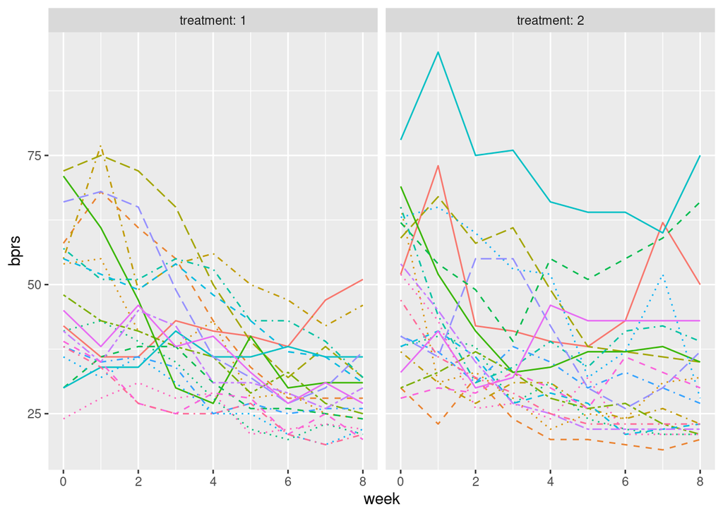

```r
# plot
ggplot(BPRS, aes(x = week, y = bprs, linetype = subject, colour = subject)) +
  geom_line() +
  scale_linetype_manual(values = rep(1:10, times=4)) +
  facet_grid(. ~ treatment, labeller = label_both) +
  theme(legend.position = "none") +
  scale_y_continuous(limits = c(min(BPRS$bprs), max(BPRS$bprs)))
```

From the plot above, we can see that the BPRS score of almost all men who participated decreased over the eight weeks of the study. Men who had higher values of BPRS in the beginning tend to have higher values throughout the study. The substantial individual differences and variability appear to decrease with time.

#### 6.2.1 Multiple regression

Ignoring the repeated-measures structure of the data, we will fit a multiple linear regression model with bprs as response and `week` and `treatment` as explanatory variables.

```r
# create a regression model
BPRS_regression_model <- lm(bprs ~ week + treatment, data = BPRS)

# print out a summary of the model
summary(BPRS_regression_model)
```

```
##
## Call:
## lm(formula = bprs ~ week + treatment, data = BPRS)
##
## Residuals:
##     Min      1Q  Median      3Q     Max
## -22.454  -8.965  -3.196   7.002  50.244
##
## Coefficients:
##             Estimate Std. Error t value Pr(>|t|)
## (Intercept)  46.4539     1.3670  33.982   <2e-16 ***
## week         -2.2704     0.2524  -8.995   <2e-16 ***
## treatment2    0.5722     1.3034   0.439    0.661
## ---
## Signif. codes:  0 '***' 0.001 '**' 0.01 '*' 0.05 '.' 0.1 ' ' 1
##
## Residual standard error: 12.37 on 357 degrees of freedom
## Multiple R-squared:  0.1851, Adjusted R-squared:  0.1806
## F-statistic: 40.55 on 2 and 357 DF,  p-value: < 2.2e-16
```

From the output above, we can see that men in treatment group 2 do not show significantly different results from men in treatment group 1. However, there is a negative correlation with week (estimate: -2.2, p < 0.001), showing that the treatments generally improved (= decreased) the BPRS score of the participants.

#### 6.2.2 The Random Intercept Model

The previous model assumes independence of the repeated measures of bprs, and this assumption is highly unlikely. So, now we will move on to consider both some more appropriate graphics and appropriate models. We will first fit the *random intercept model* for the same two explanatory variables: `Week` and `Treatment`. Fitting a random intercept model allows the linear regression fit for each male to differ in *intercept* from other males.

```r
# Create a random intercept model
BPRS_intercept_model <- lmerTest::lmer(bprs ~ week + treatment + (1 | subject), data = BPRS, REML = FALSE)
# Print the summary of the model
summary(BPRS_intercept_model)
```

```
## Linear mixed model fit by maximum likelihood . t-tests use Satterthwaite's
##   method [lmerModLmerTest]
## Formula: bprs ~ week + treatment + (1 | subject)
##    Data: BPRS
##
##      AIC      BIC   logLik deviance df.resid
##   2748.7   2768.1  -1369.4   2738.7      355
##
## Scaled residuals:
##     Min      1Q  Median      3Q     Max
## -3.0481 -0.6749 -0.1361  0.4813  3.4855
##
## Random effects:
##  Groups   Name        Variance Std.Dev.
##  subject  (Intercept)  47.41    6.885
##  Residual             104.21   10.208
## Number of obs: 360, groups:  subject, 20
##
## Fixed effects:
##             Estimate Std. Error       df t value Pr(>|t|)
## (Intercept)  46.4539     1.9090  37.2392  24.334   <2e-16 ***
## week         -2.2704     0.2084 340.0000 -10.896   <2e-16 ***
## treatment2    0.5722     1.0761 340.0000   0.532    0.595
## ---
## Signif. codes:  0 '***' 0.001 '**' 0.01 '*' 0.05 '.' 0.1 ' ' 1
##
## Correlation of Fixed Effects:
##            (Intr) week
## week       -0.437
## treatment2 -0.282  0.000
```

#### 6.2.3 Random Intercept and Random Slope Model

Now we can move on to fit the *random intercept and random slope model* to the bprs data. Fitting a random intercept and random slope model allows the linear regression fits for each individual to differ in intercept but also in slope. This way it is possible to account for the individual differences in the mens bprs profile, but also the effect of time (weeks).

```r
# create a random intercept and random slope model
BPRS_intercept_slope_model <- lmerTest::lmer(bprs ~ week + treatment + (week | subject), data = BPRS, REML = FALSE)
# print a summary of the model
summary(BPRS_intercept_slope_model)
```

```
## Linear mixed model fit by maximum likelihood . t-tests use Satterthwaite's
##   method [lmerModLmerTest]
## Formula: bprs ~ week + treatment + (week | subject)
##    Data: BPRS
##
##      AIC      BIC   logLik deviance df.resid
##   2745.4   2772.6  -1365.7   2731.4      353
##
## Scaled residuals:
##     Min      1Q  Median      3Q     Max
## -2.8919 -0.6194 -0.0691  0.5531  3.7976
##
## Random effects:
##  Groups   Name        Variance Std.Dev. Corr
##  subject  (Intercept) 64.8222  8.0512
##           week         0.9609  0.9802   -0.51
##  Residual             97.4305  9.8707
## Number of obs: 360, groups:  subject, 20
##
## Fixed effects:
##             Estimate Std. Error       df t value Pr(>|t|)
## (Intercept)  46.4539     2.1052  22.6795  22.066  < 2e-16 ***
## week         -2.2704     0.2977  19.9991  -7.626 2.42e-07 ***
## treatment2    0.5722     1.0405 320.0005   0.550    0.583
## ---
## Signif. codes:  0 '***' 0.001 '**' 0.01 '*' 0.05 '.' 0.1 ' ' 1
##
## Correlation of Fixed Effects:
##            (Intr) week
## week       -0.582
## treatment2 -0.247  0.000
```

```r
# perform an ANOVA test on the two models
anova(BPRS_intercept_model, BPRS_intercept_slope_model)
```

```
## Data: BPRS
## Models:
## BPRS_intercept_model: bprs ~ week + treatment + (1 | subject)
## BPRS_intercept_slope_model: bprs ~ week + treatment + (week | subject)
##                            npar    AIC    BIC  logLik deviance  Chisq Df
## BPRS_intercept_model          5 2748.7 2768.1 -1369.4   2738.7
## BPRS_intercept_slope_model    7 2745.4 2772.6 -1365.7   2731.4 7.2721  2
##                            Pr(>Chisq)
## BPRS_intercept_model
## BPRS_intercept_slope_model    0.02636 *
## ---
## Signif. codes:  0 '***' 0.001 '**' 0.01 '*' 0.05 '.' 0.1 ' ' 1
```

Comparing the two models with ANOVA, we can see that the model including the slope is representing the data slightly better than the one without the slope: it’s AIC is 2745.4 compared to 2748.7. However, the BIS of the first model is lower for the intercept model. We will keep trying to find the best model.

#### 6.2.4 Random Intercept and Random Slope Model with interaction

We can fit a random intercept and slope model that allows for a week × treatment interaction.

```r
# create a random intercept and random slope model with the interaction
BPRS_intercept_slope_interaction_model <- lmerTest::lmer(bprs ~ week * treatment + (week | subject), data = BPRS, REML = FALSE)
# print a summary of the model
summary(BPRS_intercept_slope_interaction_model)
```

```
## Linear mixed model fit by maximum likelihood . t-tests use Satterthwaite's
##   method [lmerModLmerTest]
## Formula: bprs ~ week * treatment + (week | subject)
##    Data: BPRS
##
##      AIC      BIC   logLik deviance df.resid
##   2744.3   2775.4  -1364.1   2728.3      352
##
## Scaled residuals:
##     Min      1Q  Median      3Q     Max
## -3.0512 -0.6271 -0.0768  0.5288  3.9260
##
## Random effects:
##  Groups   Name        Variance Std.Dev. Corr
##  subject  (Intercept) 64.9964  8.0620
##           week         0.9687  0.9842   -0.51
##  Residual             96.4707  9.8220
## Number of obs: 360, groups:  subject, 20
##
## Fixed effects:
##                 Estimate Std. Error       df t value Pr(>|t|)
## (Intercept)      47.8856     2.2521  29.6312  21.262  < 2e-16 ***
## week             -2.6283     0.3589  41.7201  -7.323 5.24e-09 ***
## treatment2       -2.2911     1.9090 319.9977  -1.200   0.2310
## week:treatment2   0.7158     0.4010 319.9977   1.785   0.0752 .
## ---
## Signif. codes:  0 '***' 0.001 '**' 0.01 '*' 0.05 '.' 0.1 ' ' 1
##
## Correlation of Fixed Effects:
##             (Intr) week   trtmn2
## week        -0.650
## treatment2  -0.424  0.469
## wek:trtmnt2  0.356 -0.559 -0.840
```

```r
# perform an ANOVA test on the two models
anova(BPRS_intercept_slope_model, BPRS_intercept_slope_interaction_model)
```

```
## Data: BPRS
## Models:
## BPRS_intercept_slope_model: bprs ~ week + treatment + (week | subject)
## BPRS_intercept_slope_interaction_model: bprs ~ week * treatment + (week | subject)
##                                        npar    AIC    BIC  logLik deviance
## BPRS_intercept_slope_model                7 2745.4 2772.6 -1365.7   2731.4
## BPRS_intercept_slope_interaction_model    8 2744.3 2775.4 -1364.1   2728.3
##                                         Chisq Df Pr(>Chisq)
## BPRS_intercept_slope_model
## BPRS_intercept_slope_interaction_model 3.1712  1    0.07495 .
## ---
## Signif. codes:  0 '***' 0.001 '**' 0.01 '*' 0.05 '.' 0.1 ' ' 1
```

The intercept slope interaction model has a slightly lower AIC of 2744.3, but the differences between the last two models are not significant (p > 0.05). Since the results of the different models do not differ greatly from one another, the random intercept slope model appears to be the best choice. It takes into account the fact that the measures of bprs are not independent and accounts for the effect of time (weeks).